# Pedigree and data exploration

Pierre-Alexandre QUITTET

2024-02-13

# **PEDIGREE ANALYSIS**

> NOTE : This document is only a summary of the results of the pedigree analysis. Data cleaning (e.g. variables format, missing parent as dummy variables…) and SQL data base importation codes are available in `PEDIGREE_ANALYSIS.R`

## I. DATA IMPORTATION

To import the data from the data base management system (DBMS), the connection to a DNN has to be set and the computer has to be parametrized (see tutorial on the GitLab “TUTO_SQL_FROM_R”).

**Here’s the DBMS information you’ll need to do so**

[marmottes]  
Description = PostgreSQL  
Driver = PostgreSQL ANSI  
Trace = No  
TraceFile = /tmp/psqlodbc.log  
Database = marmotte  
Servername = 192.168.100.56 [local] ou 134.214.35.64 [public]  
UserName = marmotte_ro  
Password = JiFlaiv3  
Port = 5432  
ReadOnly = Yes  
RowVersioning = No  
ShowSystemTables = No  
ShowOidColumn = No  
FakeOidIndex = No  
ConnSettings =

Connection with the SQL DBMS and data cleaning has been conducted in `PEDIGREE_ANALYSIS.R` script.

### **Script importation**

```r
source(file = "C:/Users/p_a_8/Documents/GitHub/marmot-quantitative-genetics/1_DATA_ANALYSIS/1_MAIN_SCRIPTS/PEDIGREE_ANALYSIS.R")
source(file = "C:/Users/p_a_8/Documents/GitHub/marmot-quantitative-genetics/1_DATA_ANALYSIS/1_MAIN_SCRIPTS/FUNCTIONS.R")
source(file = "C:/Users/p_a_8/Documents/GitHub/marmot-quantitative-genetics/1_DATA_ANALYSIS/1_MAIN_SCRIPTS/PHENOTYPES.R")
```

### **Data importation**

We import the data from the script ‘PHENOTYPE.R’.

## II. ERROR CHECK

To check the potential discrepancy in the database, I’ve made the `checking_error_pedigree()` function which test different criteria / source of error which are tested :

1. IDs are all present in the dataset i.e. if missing IDs from the whole population of the study population
2. The presence of non unique id in `individual_id`
3. Presence of an emergence date OR a capture date
4. Mismatch between emergence date and first capture date
5. Social parent in `individual_id` modalities
6. Presence of sex
7. Mismatch parents sexe e.g. if a mother is a female

```r
# ERROR CHECK
#' @param all_id : complete list of individual ID e.g. reference list (default = NULL)
#' @param individual_id : dataset individual unique IDs vector
#' @param mother_id : mother IDs vector
#' @param father_id : father IDs vector
#' @param emergence_date : emergence dates vector (default = NULL)
#' @param capture_date : capture dates vector (default = NULL)
#' @param sexe : individual's sex vector (default = NULL)

error <- checking_error_pedigree(all_id = total_individual_id$individual_id,
                                individual_id = pedigree_actu$individual_id,
                                mother_id = pedigree_actu$mere_soc,
                                father_id = pedigree_actu$pere_soc,
                                emergence_date = pedigree_actu$date_emergence,
                                capture_date = pedigree_actu$date_capture,
                                sexe = pedigree_actu$sexe
                                )
```

```
## No problem detected in the pedigree.
```

## III. MISSING DATA

Here, only **social parentality** will be considered. we test for missing parents in the pedigree. More precisely, the proportion of individual from which one parent is missing or both parent are missing.

### Descriptive statistics

| both_parents | NA_mere_soc | NA_pere_soc | NA_one_parent | NA_both_parents |
| --- | --- | --- | --- | --- |
| 1694 (80%) | 391 (18.5%) | 387 (18.3%) | 70 (3.3%) | 354 (16.7%) |

### Visualisation through years

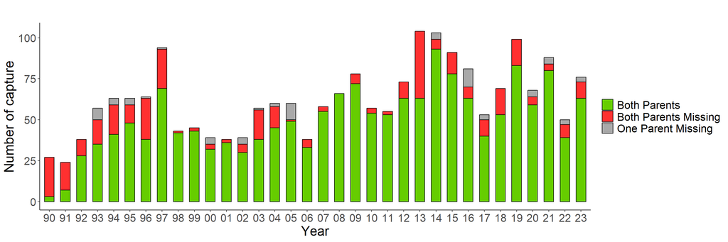

## IV. SOCIAL PEDIGREE

### **Construction and formatting of the pedigree**

```r
# SOCIAL
pedigree_data <-
  data.frame(
    individual_id = pedigree_actu$individual_id,
    mother = pedigree_actu$mere_soc,
    father = pedigree_actu$pere_soc,
    sexe = pedigree_actu$sexe,
    emergence = pedigree_actu$date_emergence
  )

# GENETIC
pedigree_data_gen <-
  data.frame(
    individual_id = pedigree_actu$individual_id,
    mother = pedigree_actu$mere_gen,
    father = pedigree_actu$pere_gen,
    sexe = pedigree_actu$sexe,
    emergence = pedigree_actu$date_emergence
  )
```

#### Missing parent as dummy variables

We replace the missing parent by a dummy variable for each parent. **A FILTRER PAR ANNEE**.

```r
# One missing parent == NA as dummy_variable parent
row_missing_parent <- which(xor(is.na(pedigree_data$mother), is.na(pedigree_data$father)))
missing_parent <- pedigree_data[row_missing_parent,]
id_single_mother <- names(table(missing_parent$mother))  # mother's id from missing father family
id_single_father <- names(table(missing_parent$father))  # father's id from missing mother family

 # Replace 'NA' of missing father for each family by a dummy father D[i]
for(i in 1:length(id_single_mother)){
  rows_missing_father <- which(pedigree_data$mother == id_single_mother[i] & is.na(pedigree_data$father))
  pedigree_data[rows_missing_father, "father"] <- paste0("Df",i)
  # adding dummy parent as dummy individual in individual ID column
  pedigree_data[rows_missing_father, "father"] <- paste0("Df",i)
  pedigree_data[nrow(pedigree_data)+1, c("individual_id", "sexe")] <- c(paste0("Df",i), "m")
}

# Replace 'NA' of missing mother for each family by a dummy mother D[i]
for(i in 1:length(id_single_father)){
  rows_missing_mother <- which(pedigree_data$father == id_single_father[i] & is.na(pedigree_data$mother))
  pedigree_data[rows_missing_mother, "mother"] <- paste0("Dm",i)
  # adding dummy parent as dummy individual in individual ID column
  pedigree_data[rows_missing_mother, "mother"] <- paste0("Dm",i)
  pedigree_data[nrow(pedigree_data)+1, c("individual_id", "sexe")] <- c(paste0("Dm",i), "f")
}
```

#### Ordering pedigree

Offsprings must follow parents. This step is needed for the function of the `kinship2` package to work properly (and for animal model).

```r
# SOCIAL
pedigree_data <- pedigree_data[nrow(pedigree_data):1,]
ord <- pedigree::orderPed(pedigree_data)
pedigree_data <- pedigree_data[order(ord),]

#GENETIC
pedigree_data_gen <- pedigree_data_gen[nrow(pedigree_data_gen):1,]
ord <- pedigree::orderPed(pedigree_data_gen)
pedigree_data_gen <- pedigree_data_gen[order(ord),]
```

#### Error check

We’ll re-use the `checking_error_pedigree()` function to check if all criteria are met.

```r
# SOCIAL
error_ordered_pedigree <-
  checking_error_pedigree(
  individual_id = pedigree_data$individual_id,
  mother_id = pedigree_data$mother,
  father_id = pedigree_data$father,
  sexe = pedigree_data$sexe
)
```

```
## No problem detected in the pedigree.
```

```r
# GENETIC
error_ordered_pedigree_gen <-
  checking_error_pedigree(
  individual_id = pedigree_data_gen$individual_id,
  mother_id = pedigree_data_gen$mother,
  father_id = pedigree_data_gen$father,
  sexe = pedigree_data_gen$sexe
)
```

```
## No problem detected in the pedigree.
```

### **General description**

#### Pedigree depth

```r
# GENERATION PEDIGREE FOR KINSHIP2
ped <- with(pedigree_data, kinship2::pedigree(id = individual_id, dadid = father, momid = mother, sex = sexe))

# DEPTH OF PEDIGREE
ped_depth <- kindepth(ped)
```

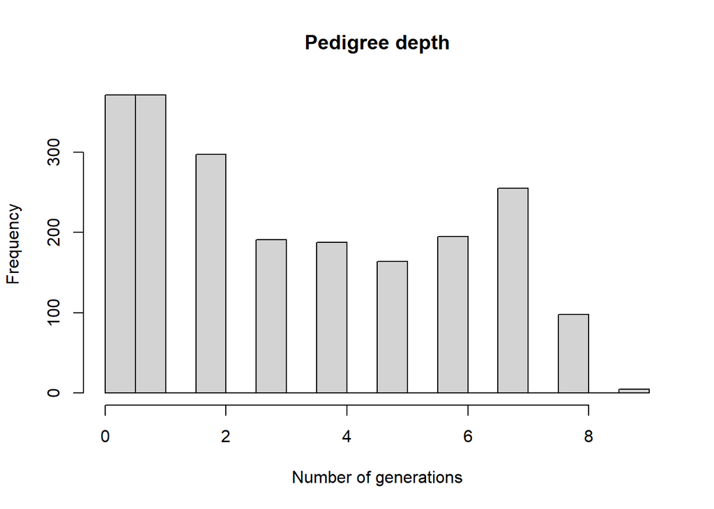

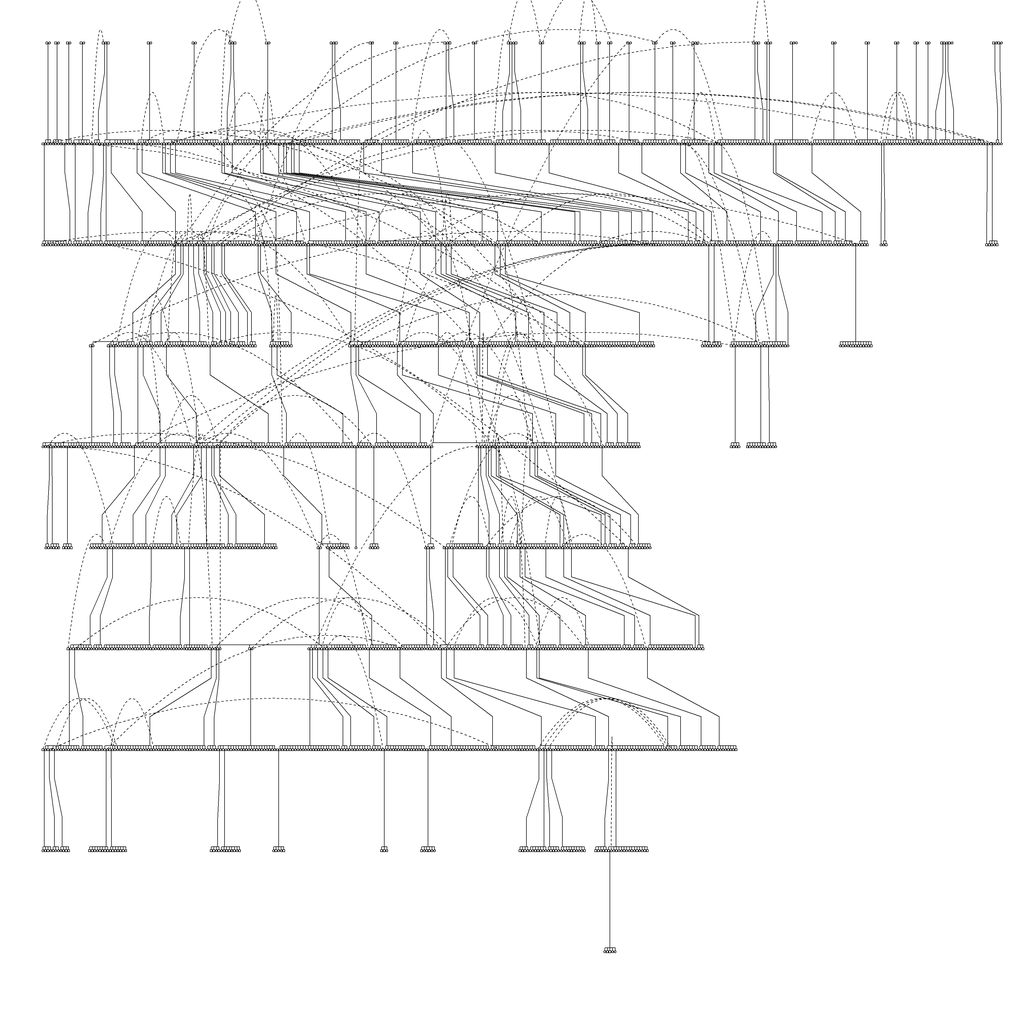

```
## Did not plot the following people: 9999 2290 2287 2280 2279 2276 2267 2264 2220 2219 2217 2177 2170 2169 2168 2167 2166 2165 2080 2077 2061 2059 2057 2047 1989 1984 1983 1979 1973 1972 1969 1965 1964 1958 1943 1914 1912 1909 1903 1896 1890 1885 1884 1883 1882 1847 1846 1843 1823 1819 1811 1795 17…
```

```r
ped <- with(pedigree_data, kinship2::pedigree(id = individual_id, dadid = father, momid = mother, sex = sexe))
plot.pedigree(ped, id = rep("", nrow(pedigree_data)))  # Plot pedigree
```

#### Pedigree composition

**Summary**  
The `pedantics::pedigreeStats()` function might be quite long to run.

```r
# SOCIAL
stats_ped_soc <- pedantics::pedigreeStats(pedigree_data[1:3], graphicalReport = "n")
format(round(pedantics::pedStatSummary(stats_ped_soc), 2), scientific = F)
```

```
##                    records                  maternities
##                  " 2135.00"                  " 1764.00"
##                 paternities                   full sibs
##                  " 1764.00"                  " 9151.00"
##               maternal sibs          maternal half sibs
##                  "13124.00"                  " 3973.00"
##               paternal sibs          paternal half sibs
##                  "12088.00"                  " 2937.00"
##       maternal grandmothers       maternal grandfathers
##                  " 1160.00"                  " 1160.00"
##       paternal grandmothers       paternal grandfathers
##                  " 1121.00"                  " 1121.00"
##      maximum pedigree depth                    founders
##                  "    9.00"                  "  371.00"
##   mean maternal sibsip size   mean paternal sibsip size
##                  "   10.82"                  "   10.08"
##                  non-zero F                   F > 0.125
##                  "  640.00"                  "  297.00"
##   mean pairwise relatedness pairwise relatedness>=0.125
##                  "    0.03"                  "    0.11"
##  pairwise relatedness>=0.25   pairwise relatedness>=0.5
##                  "    0.05"                  "    0.01"
```

```r
# GENETIC
stats_ped_gen <- pedantics::pedigreeStats(pedigree_data_gen[1:3], graphicalReport = "n")
format(pedantics::pedStatSummary(stats_ped_gen), scientific = F)
```

```
##                    records                  maternities
##            "2153.000000000"            "1248.000000000"
##                 paternities                   full sibs
##            "1248.000000000"            "5575.000000000"
##               maternal sibs          maternal half sibs
##            "9158.000000000"            "3583.000000000"
##               paternal sibs          paternal half sibs
##            "7351.000000000"            "1776.000000000"
##       maternal grandmothers       maternal grandfathers
##            " 810.000000000"            " 810.000000000"
##       paternal grandmothers       paternal grandfathers
##            " 738.000000000"            " 738.000000000"
##      maximum pedigree depth                    founders
##            "   8.000000000"            " 905.000000000"
##   mean maternal sibsip size   mean paternal sibsip size
##            "  10.487394958"            "   7.473053892"
##                  non-zero F                   F > 0.125
##            " 360.000000000"            " 163.000000000"
##   mean pairwise relatedness pairwise relatedness>=0.125
##            "   0.014519519"            "   0.049332046"
##  pairwise relatedness>=0.25   pairwise relatedness>=0.5
##            "   0.022539225"            "   0.005064689"
```

#### Relatedness and inbreeding

**Relatedness**

```r
# SOCIAL
relatedness <-  stats_ped_soc$relatednessCategories
relatedness
```

```
##       0   0.025    0.05   0.075     0.1   0.125    0.15   0.175     0.2   0.225
## 1686555  120052  113347   49843   49611   58237   30569   31650   15851   17176
##    0.25   0.275     0.3   0.325    0.35   0.375     0.4   0.425    0.45   0.475
##   32030   11756   11209    6050    4091    7813    5014    2360    2005    1990
##     0.5   0.525    0.55   0.575     0.6   0.625    0.65   0.675     0.7   0.725
##   10288    2376    1600    1123     744    1646     534     422     369     165
##    0.75   0.775     0.8   0.825    0.85   0.875     0.9   0.925    0.95   0.975
##     490     502     395       8      92      28      16      10      28       0
```

```r
# GENETIC
relatedness_gen <- stats_ped_gen$relatednessCategories
relatedness_gen
```

```
##       0   0.025    0.05   0.075     0.1   0.125    0.15   0.175     0.2   0.225
## 2084827   46565   41997   13891   15064   31478    9970   10832    4342    5447
##    0.25   0.275     0.3   0.325    0.35   0.375     0.4   0.425    0.45   0.475
##   19380    4837    4276    2129    1462    4259    1782    1415     580     362
##     0.5   0.525    0.55   0.575     0.6   0.625    0.65   0.675     0.7   0.725
##    7623     572     683     369     314     894     122     146     192      48
##    0.75   0.775     0.8   0.825    0.85   0.875     0.9   0.925    0.95   0.975
##     312      96     260       2      59      30       0      11       0       0
```

**Inbreeding**

```r
inbreeding <- pedigree::calcInbreeding(pedigree_data)  # distribution based on pedigree data
```

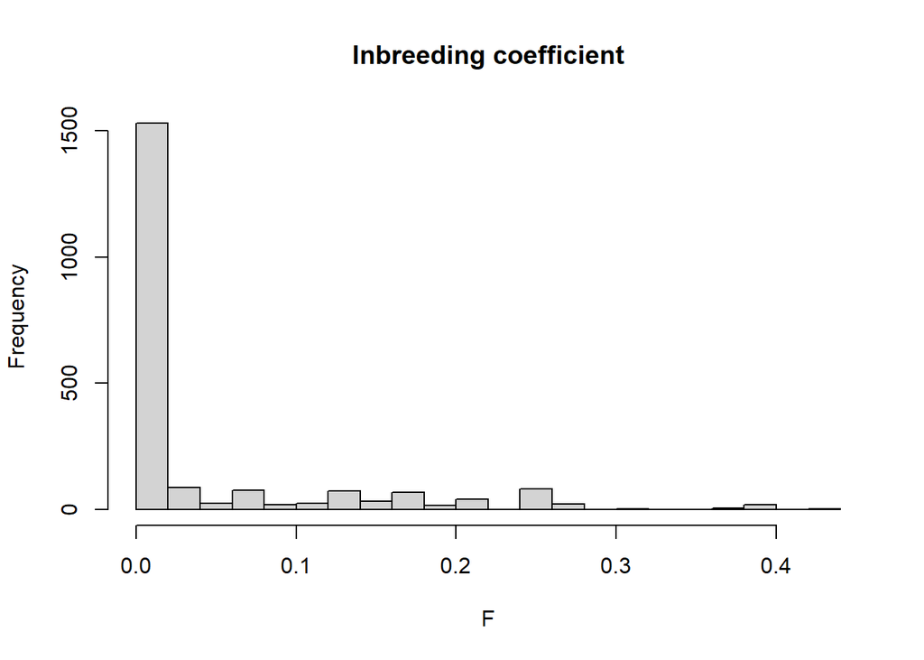

**Comparison with genetic pedigree**

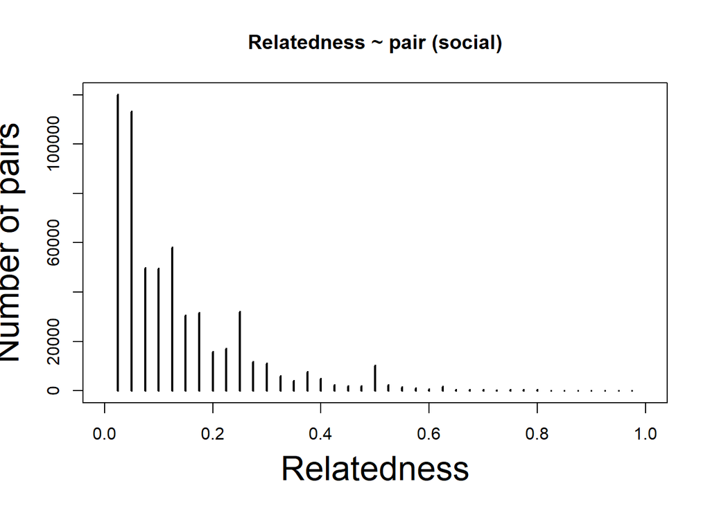

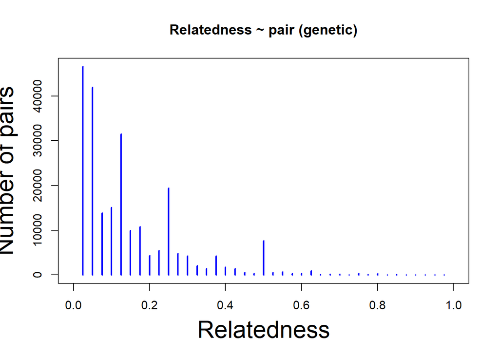

```r
# Select only individual with genetic measures for social pedigree (to allow comparison)
ped_soc <- with(pedigree_data, kinship2::pedigree(id = individual_id, dadid = father, momid = mother, sex = sexe))
ped_gen <- with(pedigree_data_gen, kinship2::pedigree(id = individual_id, dadid = father, momid = mother, sex = sexe))

mat_ped_soc <- kinship2::kinship(ped_soc)
mat_ped_gen <- kinship2::kinship(ped_gen)
```

#### Pedigree pruning

Pruning a pedigree means removing non-informative individuals (e.g. individual with no phenotype data or individuals from which we could not infer any genetic parameters).

```r
# ONLY CONSIDER DATA USABLE FOR ANIMAL MODEL (NO NAs)
pheno_complete <- pheno[!is.na(pheno$annee_emergence) &
                      !is.na(pheno$age_emergence) &
                      !is.na(pheno$litter_size_naissance) &
                      !is.na(pheno$territoire) &
                      !is.na(pheno$taille_groupe_naissance),]
```

```r
#' [PRUNING]
 for(response_variable in c("masse", "tibia", "cubitus", "zygo", "longueur_corps", "mandibule")){
    # No NAs response variable
    informative_id <- pheno_complete[which(!is.na(pheno_complete[response_variable])), 'individual_id']

    # Pruning pedigree according to available data
    pruned_pedigree <- prunePed(pedigree = pedigree_data[1:3],
            keep = informative_id,  # IDs of informative individual (i.e. with measures)
            make.base = T)

    # Number of individual pruned
    amplitude_prune <-  nrow(pedigree_data) - nrow(pruned_pedigree)

    print(
      paste0(toupper(x = response_variable), " : NUMBER OF PRUNED INDIVIDUAL = ", amplitude_prune)
      )
 }
```

```
## [1] "MASSE : NUMBER OF PRUNED INDIVIDUAL = 589"
## [1] "TIBIA : NUMBER OF PRUNED INDIVIDUAL = 691"
## [1] "CUBITUS : NUMBER OF PRUNED INDIVIDUAL = 691"
## [1] "ZYGO : NUMBER OF PRUNED INDIVIDUAL = 678"
## [1] "LONGUEUR_CORPS : NUMBER OF PRUNED INDIVIDUAL = 598"
## [1] "MANDIBULE : NUMBER OF PRUNED INDIVIDUAL = 591"
```

## V. EXPLORATION

Note that `mere_soc` / `pere_soc` represent the social mother / father association of the individual based on social dominance at birth and `mere_gen` / `pere_gen` represent the mother / father association of the individual based on genetic data.

### Age of mother

**Pooled**

```r
# DATA USED
data <- data_mcmc_biv_marmotton


# SELECT COHORT FOR WHICH FITNESS CAN BE CALCULATED -----------------------
data <- data[!data$annee_emergence %in% c(1990, 1991, 1994, 1996, 2021, 2022, 2023),]
data$annee_emergence <- factor(data$annee_emergence, levels = c(1992:1993, 1995, 1997:2020))



# AGE OF REPRODUCTION
# --- Get mother ID and cohort
mother_id <- unique(pedigree_data$mother)
df_mother <- data.frame(individual_id = mother_id[-1])
df_mother <- merge(df_mother, pheno[c("individual_id", "annee_emergence")], by = "individual_id")

# --- Age of reproduction == cohort of offspring - cohort mother
pup_mother <- data$mother  # mother of each row in dataset
pup_mother_index <- match(pup_mother, df_mother$individual_id)  # get the mother index in the mother df of reference
age_mother <- as.numeric(as.character(data$annee_emergence)) - as.numeric(as.character(df_mother[pup_mother_index, "annee_emergence"]))  # calculate the age in year of reproduction of the mother for each row
```

```r
# MEAN GENERATION TIME
mean(age_mother, na.rm = T)
```

```
## [1] 5.939073
```

**Cumulative**

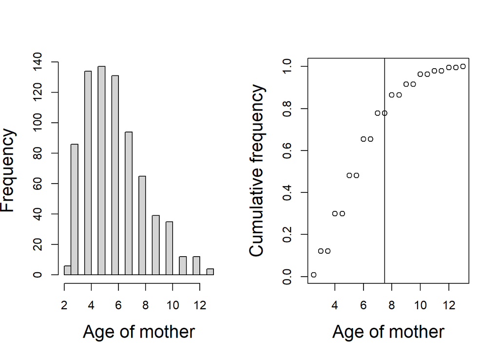

### Number of parent

```r
nb_mother <- length(unique(pedigree_data$mother))
nb_father <- length(unique(pedigree_data$father))
```

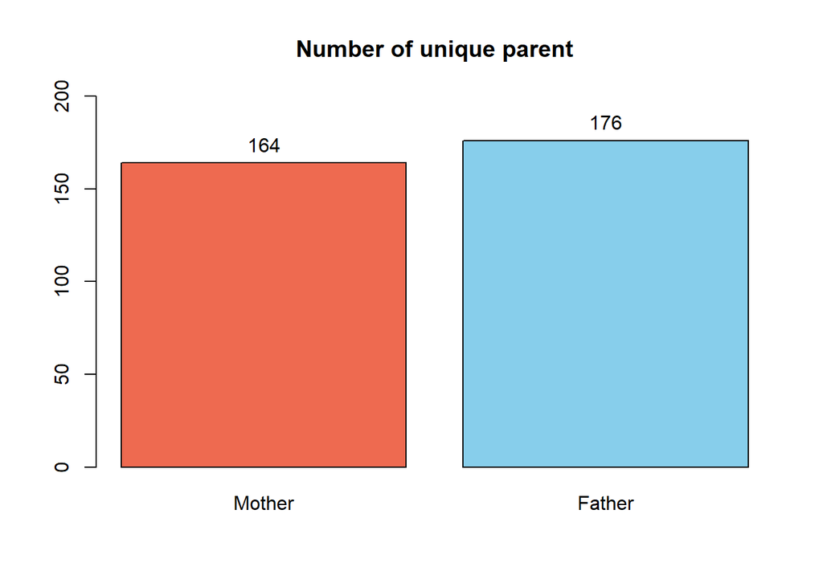

### Litter size per mother / father

```r
med_f <- median(table(pedigree_data$mother))  # social mother
q_f <- quantile(x = table(pedigree_data$mother), probs = c(.25, .75))

med_m <- median(table(pedigree_data$father))  # social father
q_m <- quantile(x = table(pedigree_data$father), probs = c(.25, .75))
```

```
## [1] "FEMALE : NUMBER OF OFFSPRINGS : 10 (Q1=4, Q2=16)"
```

```
## [1] "MALE : NUMBER OF OFFSPRINGS : 8 (Q1=4, Q2=15)"
```

```r
# MOTHER
table(table(c(pedigree_data$mother)))
```

```
##
##  1  2  3  4  5  6  7  8  9 10 11 12 13 14 15 16 17 18 19 20 21 22 23 24 26 27
##  5  4 16 22 10  6  4  7  7 10  5  7  9  4  4  4  3  4  7  5  7  1  1  4  1  2
## 28 32 34
##  2  1  1
```

```r
# FATHER
table(table(c(pedigree_data$father)))
```

```
##
##  1  2  3  4  5  6  7  8  9 10 11 12 13 14 15 16 17 18 19 20 21 22 23 24 25 26
##  5  8 12 24 13 11  8  7 10 10  4  5  6  2  9  5  5  5  6  3  4  3  1  2  3  2
## 27 29
##  1  1
```

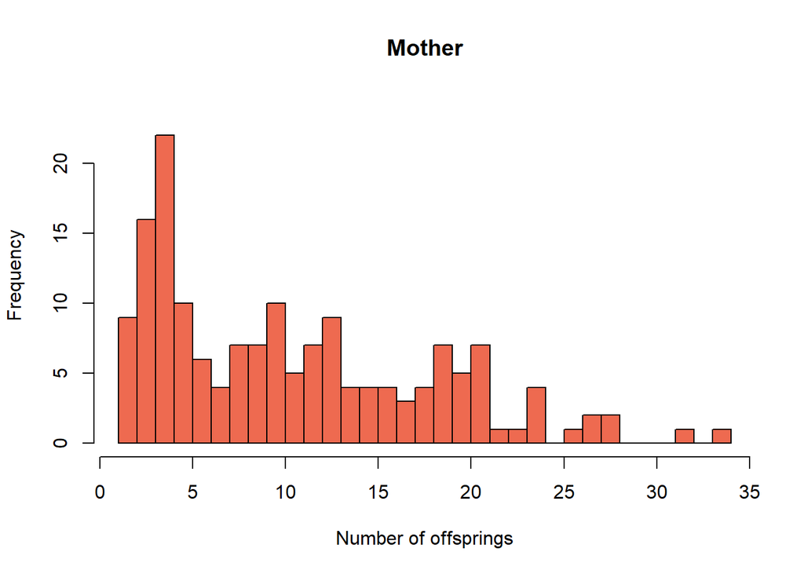

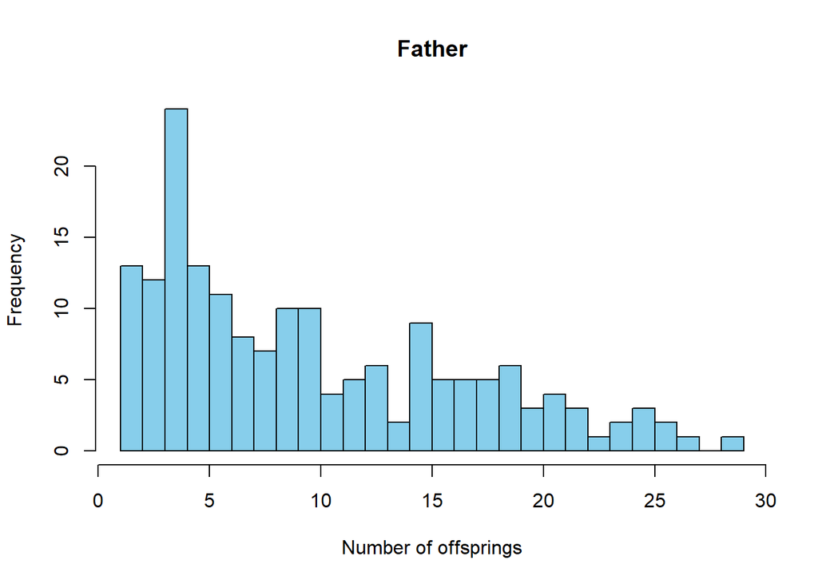

### Number of partner per mother/father

```r
partner_per_mother <-
  pedigree_data %>%
  group_by(mother) %>%
  summarise(partner_per_mother = n_distinct(father)) %>%
  as.data.frame()


partner_per_father <-
  pedigree_data %>%
  group_by(father) %>%
  summarise(partner_per_father = n_distinct(mother)) %>%
  as.data.frame()
```

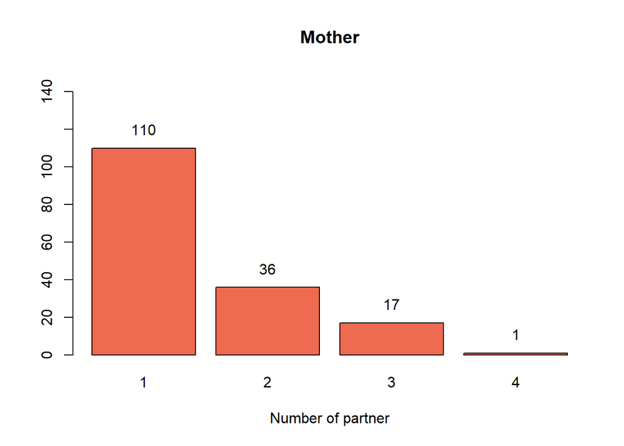

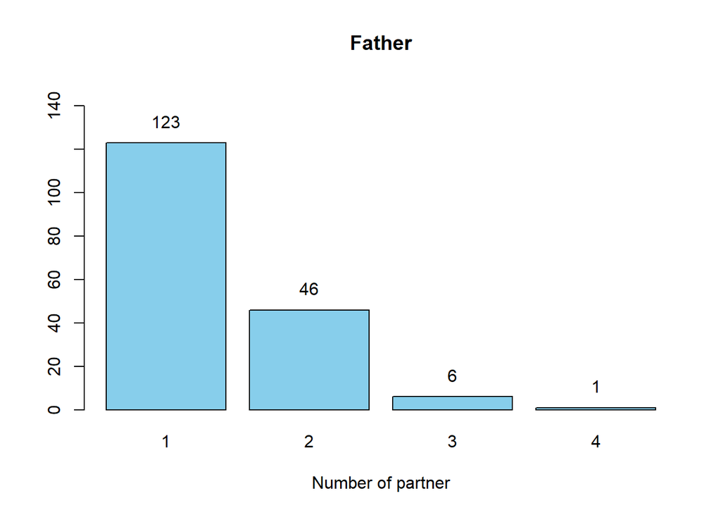

### Number of recruits

```r
repro <- pedigree_data %>%
  filter(individual_id %in% mother | individual_id %in% father)
```

```
## [1] "PEDIGREE RECRUITS : 338 (15.8%)"
```

### Number of families

We create a variable that concatenate [mother’s ID ; father’s ID] to get the families.

```r
# NUMBER OF FAMILIES
pedigree_data["family"] <- paste0(pedigree_data$mother, ";", pedigree_data$father)
family_na <- sum(grepl(pattern = "NA", x = names(table(pedigree_data$family))))  # number of family with at least one unkown parent
nb_family <- length(table(pedigree_data$family)) - family_na
```

```
## [1] "NUMBER OF FAMILY : 236"
```

### Extra pair reproduction

```r
nb_extra_pair_repro_male <- sum(pedigree_actu$mere_soc != pedigree_actu$mere_gen, na.rm = T)   # male
nb_extra_pair_repro_female <- sum(pedigree_actu$pere_soc != pedigree_actu$pere_gen, na.rm = T)  # female

percentage_extra_pair_repro_male <- sum(pedigree_actu$mere_soc != pedigree_actu$mere_gen, na.rm = T) / sum(pedigree_actu$mere_soc == pedigree_actu$mere_gen, na.rm = T) * 100  # male
percentage_extra_pair_repro_female <- sum(pedigree_actu$pere_soc != pedigree_actu$pere_gen, na.rm = T) / sum(pedigree_actu$pere_soc == pedigree_actu$pere_gen, na.rm = T) * 100  # female
```

```
## [1] "EXTRA PAIR REPRODUCTION MALE : 8 (0.65%)"
```

```
## [1] "EXTRA PAIR REPRODUCTION FEMALE : 68 (6.04%)"
```

# **BIOMETRIC DATA ANALYSIS**

> NOTE : This document is only a summary of the results of the pedigree analysis. Data cleaning and SQL data base importation codes are available in `PHENOTYPES.R`

## I. DATA IMPORTATION

```r
source(file = "C:/Users/p_a_8/Documents/GitHub/marmot-quantitative-genetics/1_DATA_ANALYSIS/1_MAIN_SCRIPTS/PHENOTYPES.R")
```

## II. GENERATION OF THE SOCIAL VARIABLES

> Note that here, social variables generation code are not evaluated. The ‘effective’ code that generate them is in `PHENOTYPE.R`

### Sex ratio of the subordinates

Sex ratio is calculated as : $\frac{male - 1}{(male-1) + (female-1)}$. The ‘-1’ aims to remove the dominant couple to only consider subordinates. Only adults and 2 years old individuals were included in this calcul.

```r
pheno["sex_ratio_subordinates"] <-
  apply(pheno, 1, function(x) {
    male_sub <-
      ifelse((as.numeric(x["compo_m_2"]) + as.numeric(x["compo_m_ad"]) - 1) <= 0,
             0, (as.numeric(x["compo_m_2"]) + as.numeric(x["compo_m_ad"]) - 1))
    female_sub <-
      ifelse((as.numeric(x["compo_f_2"]) + as.numeric(x["compo_f_ad"]) - 1) <= 0,
             0, (as.numeric(x["compo_f_2"]) + as.numeric(x["compo_f_ad"]) - 1))

    return(ifelse(male_sub == 0 & female_sub == 0, NA, male_sub / (male_sub + female_sub)
    ))
  })
```

### Number of male subordinates

**Quantitative**

```r
pheno["nb_male_subordinates"] <- (pheno$compo_m_2 + pheno$compo_m_ad - 1)
pheno[pheno$nb_male_subordinates < 0 & !is.na(pheno$nb_male_subordinates), "nb_male_subordinates"] <- 0
```

**Binary**

```r
pheno["presence_male_subordinates"] <- pheno["nb_male_subordinates"]

# Binomial coding
pheno[pheno$presence_male_subordinates > 0 &
        !is.na(pheno$presence_male_subordinates < 0), "presence_male_subordinates"] <- 1
```

### Litter size / group size / composition of the group at birth

we selection the state of social variables (sex ratio of subordinates, group size…) at the emergence date of the individual to characterize the social status of the group at birth for each individual.

```r
# SELECT SOCIAL VARIABLES AT THE EMERGENCE DATE
ref_birth <-
  pheno %>%
  filter(annee_emergence == annee_territoire) %>%  # select the social group state at emergence's year
  dplyr::select(
    c(
      individual_id,
      taille_groupe,
      litter_size,
      sex_ratio_subordinates,
      nb_male_subordinates,
      presence_male_subordinates
    )
  ) %>%  # /!\ select enters in conflict with MASS::select() if not specified dplyr::
  distinct(individual_id, .keep_all = T)  # filtering repeated observations to only take one (to remove individual recaptured the same year of their emergence)



# RENAMING NEW VARIABLES
names(ref_birth)[2:ncol(ref_birth)] <-
  c(
    "taille_groupe_naissance",
    "litter_size_naissance",
    "sex_ratio_subordinates_naissance",
    "nb_male_subordinates_naissance",
    "presence_male_subordinates_naissance"
  )

# MERGING WITH DATASET
pheno <- merge(x = pheno, y = ref_birth, by = "individual_id", all = T, all.y = T, sort = F)
```

## III. ERROR CHECK

The function `checking_error_data()` checks for :

- The uniqueness of capture IDs
- The presence of all individual IDs from the dataset in the pedigree
- The presence of all individual IDs from the pedigree in the dataset
- Mismatch between the year of capture and the year of territory observation
- Presence of measures at emergence while litter size == 0
- Group size is not equal to the sum of adults + young (1 year) + yearling
- Group size == NA while group composition is available
- Presence of some NAs (not all) in group composition

```r
#' @param capture_id : a vector containing all the capture IDs
#' @param pedigree_individual_id : a vector containing all the individual IDs of the pedigree
#' @param data_individual_id : a vector containing all the individual IDs of the dataset
#' @param capture_year : a vector containing the capture's years
#' @param territoire_year : a vector containing the observation's territory years
#' @param litter_size_at_birth : a vector containing the litter size at birth
#' @param df_group_composition : a data_frame containing the group size in first column and one year adults and yearlings for the other

error_data <- checking_error_data(
  capture_id = pheno$capture_id,
  pedigree_individual_id = pedigree_data$individual_id,
  data_individual_id = pheno$individual_id,
  capture_year = pheno$annee_capture,
  territoire_year = pheno$annee_territoire,
  litter_size_at_birth = pheno$litter_size_naissance,
  df_group_composition = pheno[c(which(names(pheno) == "taille_groupe"),
                                 # select all but pups
                                 which(names(pheno) %in% grep(pattern = "compo", x = names(pheno), value = T) &
                                         !(names(pheno) %in% grep(pattern = "0", x = names(pheno), value = T))))]
  )
```

```
##
## ======================================================================
## ========================== PROBLEM DETECTED ==========================
## ======================================================================
##
##  INDIVIDUAL IDs IN PEDIGREE BUT NOT IN DATASET :
##  Dm9 Dm8 Dm7 Dm6 Dm5 Dm4 Dm3 Dm2 Dm1 Df8 Df7 Df6 Df5 Df4 Df3 Df2 Df1 1969 1965 1964 1958 1882 1771 1617 1616 1615 1614 1613 1612 1611 1609 1608 1607 1595 1486 1402 1047 1004 991 987 985 859 257 165 428 427 425 424 423 406 403 347 259 258 56
##
## PRESENCE OF NAs IN GROUP COMPOSITION (!= ALL NAs), CAPTURE ID :
##  10259 1531 3102 2132 3046 3030 3096 3173 3284 3031 3072 2964 3181 2956 3132 3152 3052 3084 3010 3092 3086 3085 3201 3135 3047 3112 3097 2965 3156 3331 10497 3191 3093 3178 3043 2980 3053 3154 3163 3022 3133 3095 3110 3061 2982 3111 3164 3070 3192 3134 3172 3155 3124 3045 2993 2995 3101 3151 3089…
##
##
##
## [You can access problematic rows by creating an object with the function's results using object$...]
```

## IV. MISSING DATA

### Size data

| observations | masse_NA | tibia_NA | cubitus_NA | zygo_NA | mandibule_NA | pattes_anterieures_NA | pattes_posterieures_NA | longueur_corps_NA | bassin_NA |
| --- | --- | --- | --- | --- | --- | --- | --- | --- | --- |
| 2080 | 4 (0.2%) | 323 (15.5%) | 322 (15.5%) | 274 (13.2%) | 30 (1.4%) | 145 (7%) | 146 (7%) | 42 (2%) | 277 (13.3%) |

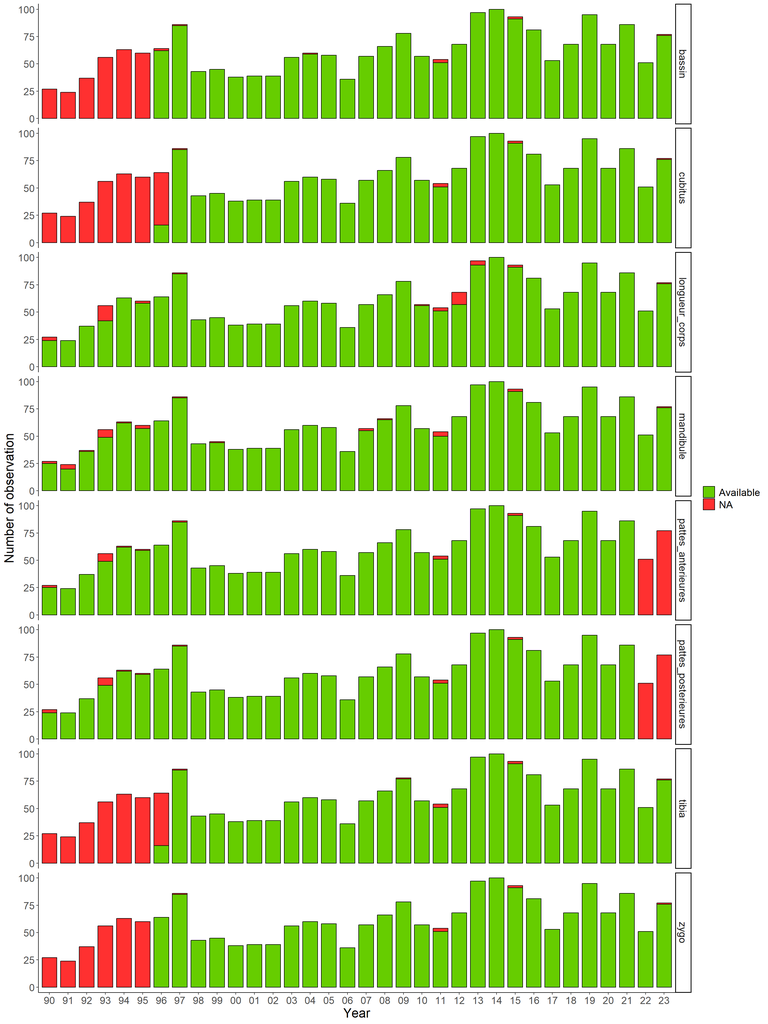

### Weight data

| observations | masse_NA |
| --- | --- |
| 6458 | 34 (0.53%) |

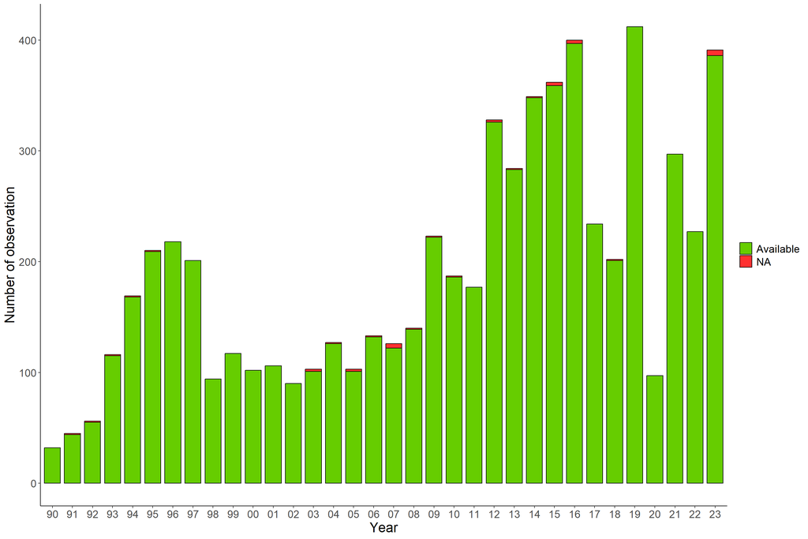

### Group composition

With `M` = male, `F` = female, `U` = unkown, `a` = adult and `[number]` is the age in year (e.g. 0 is for pups).

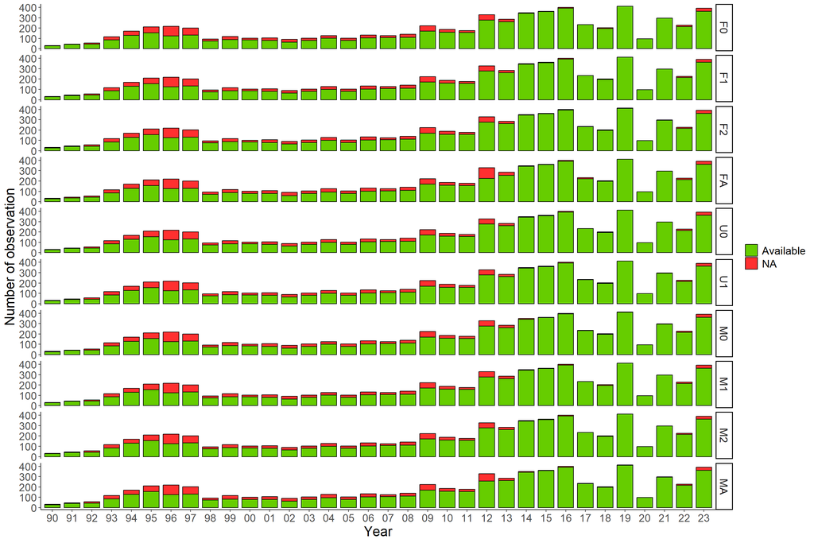

### Individual caught at emergence

Those represent the individuals that were caught as pups, meaning their age is availaible and calculated as ‘age since emergence from the burrow’.

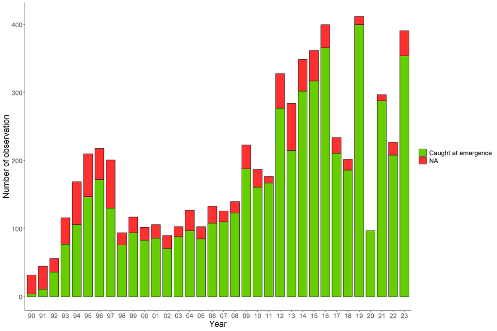

## V. DATA VISUALISATION

### **Non-social variables**

#### Size ~ weight

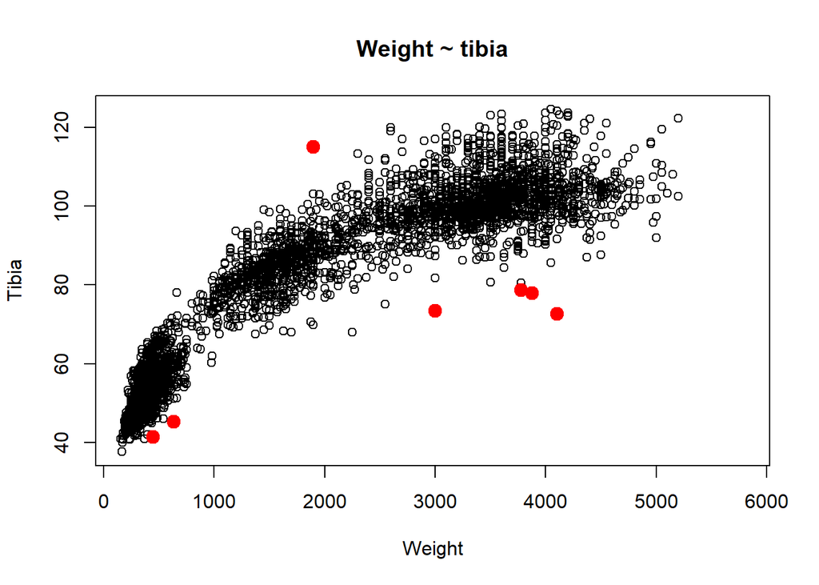

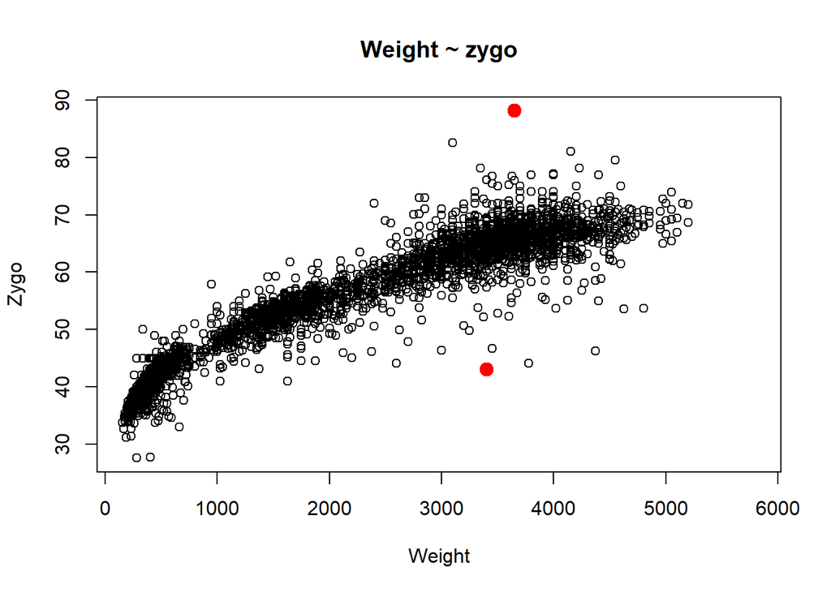

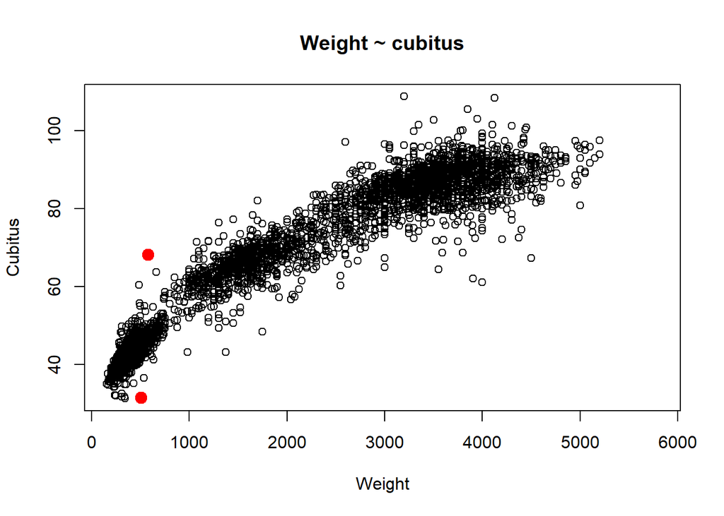

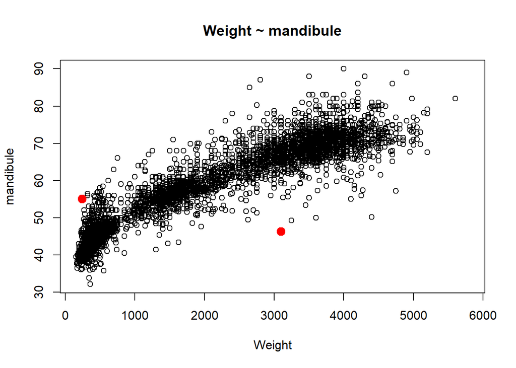

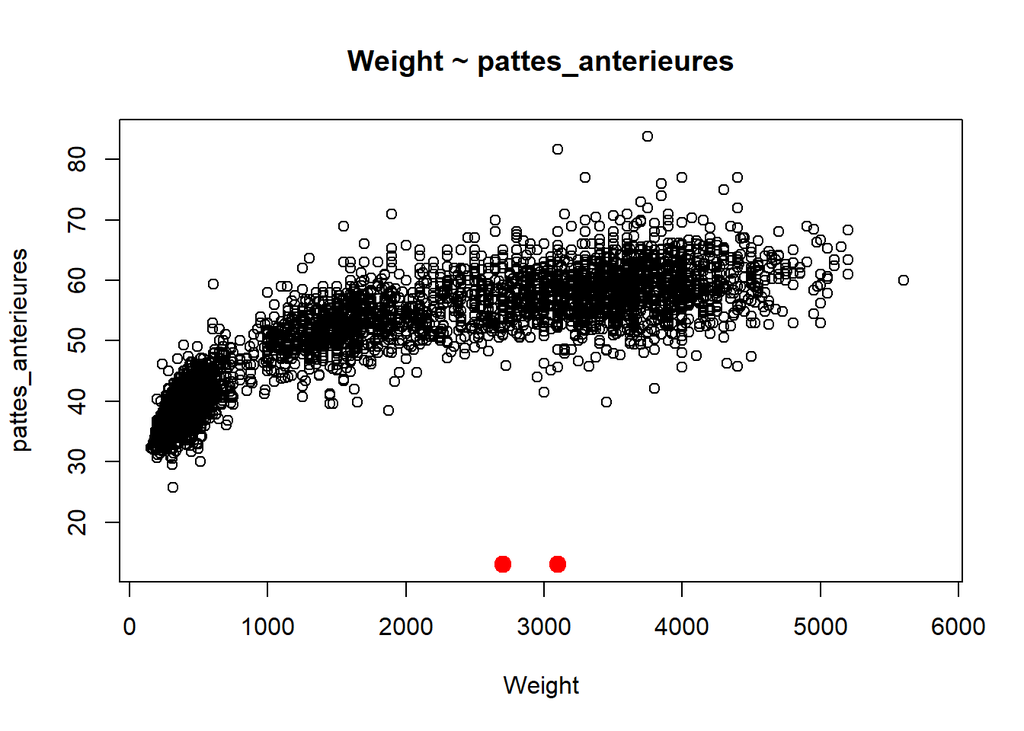

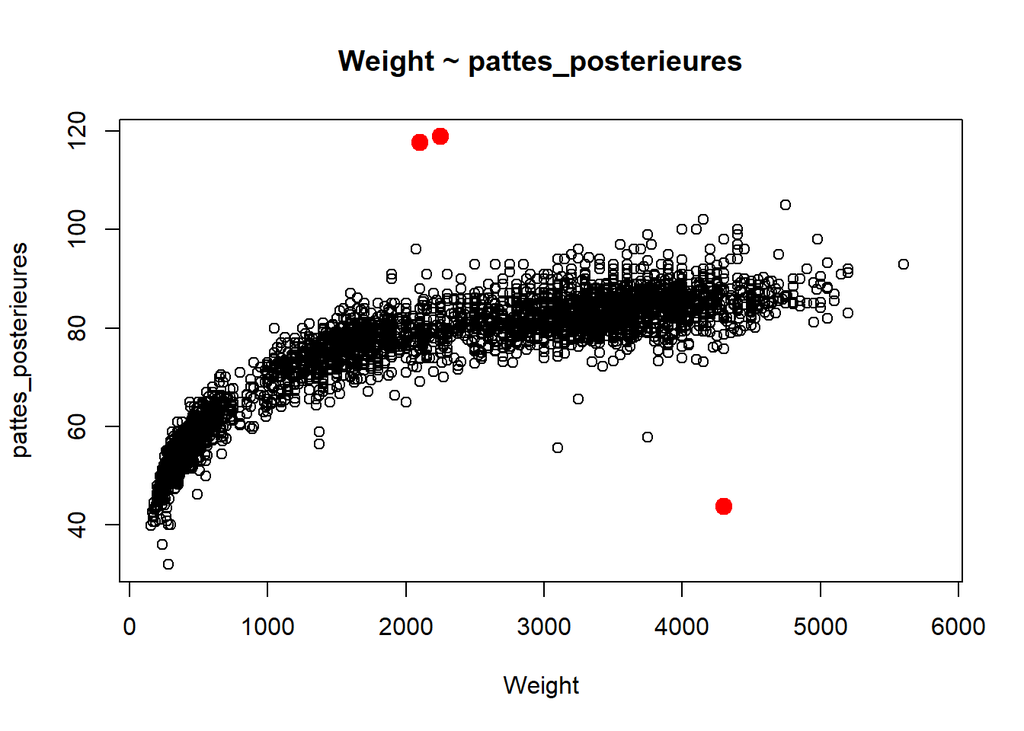

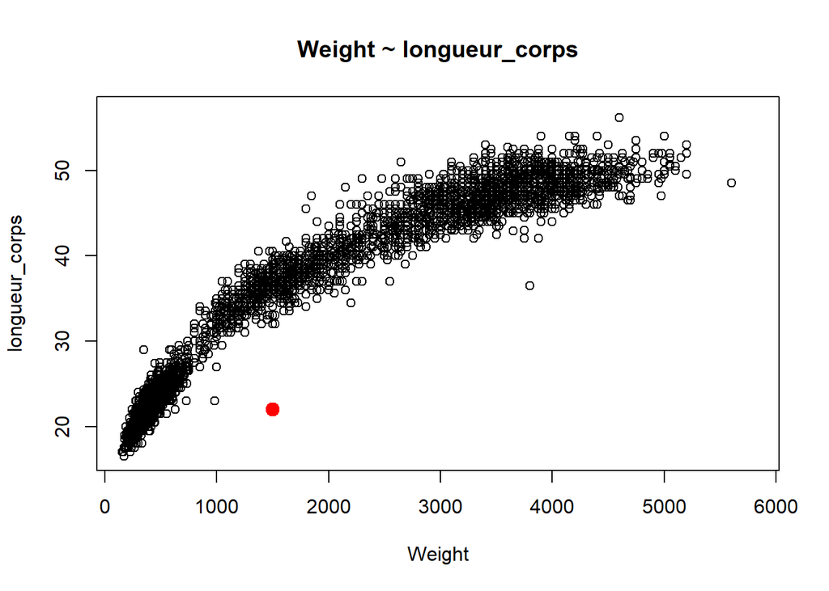

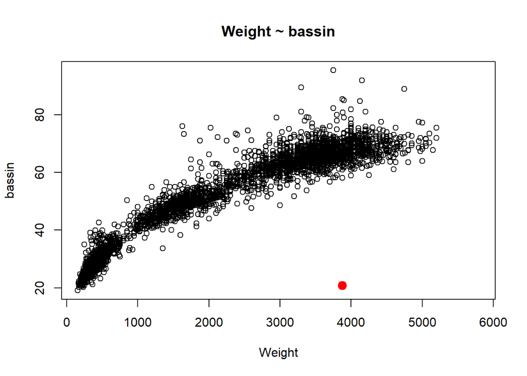

#### Size / weight ~ age

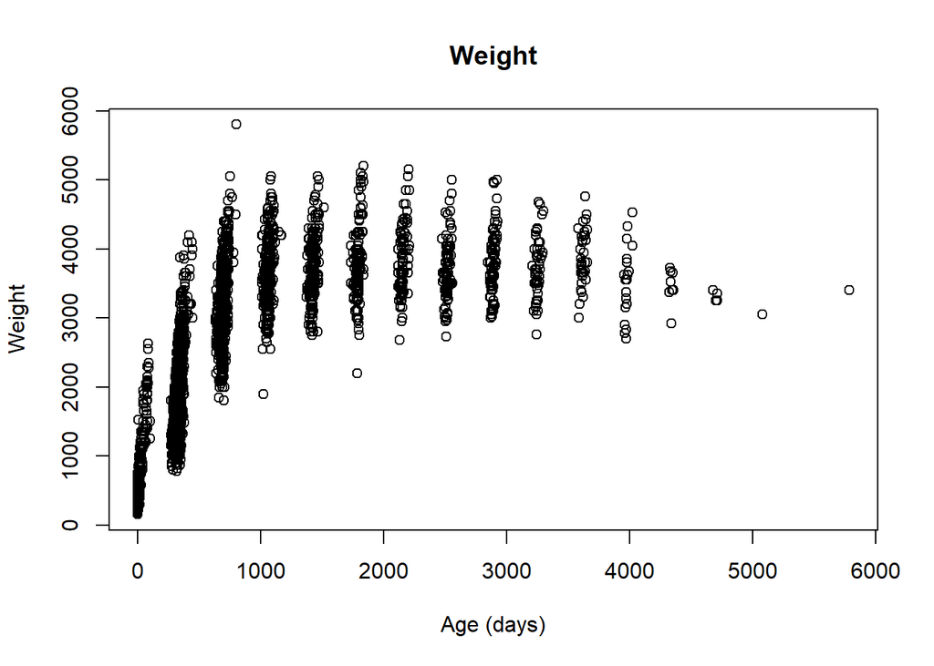

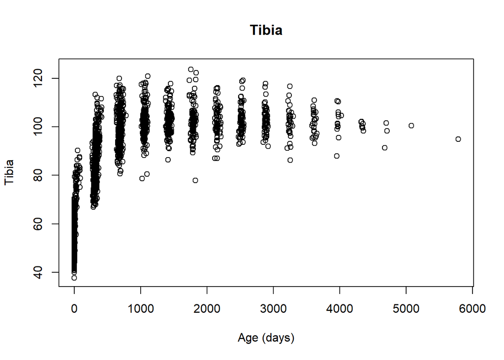

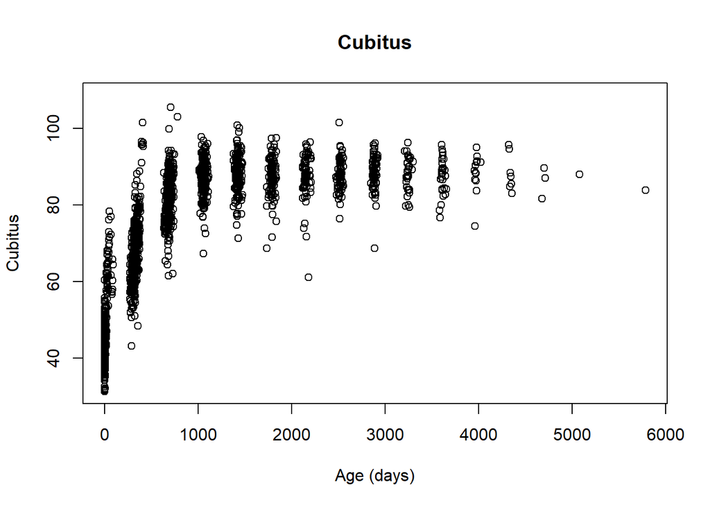

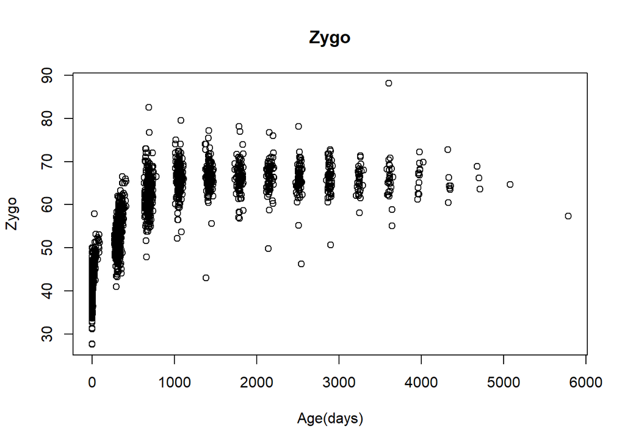

#### Inbreeding

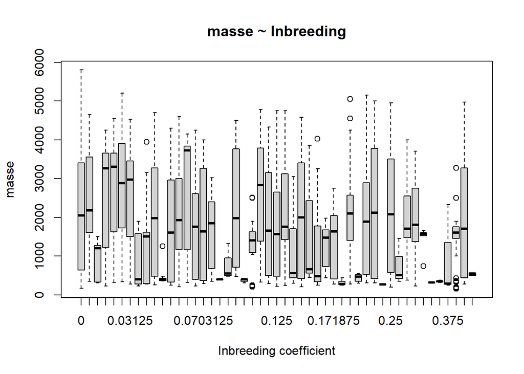

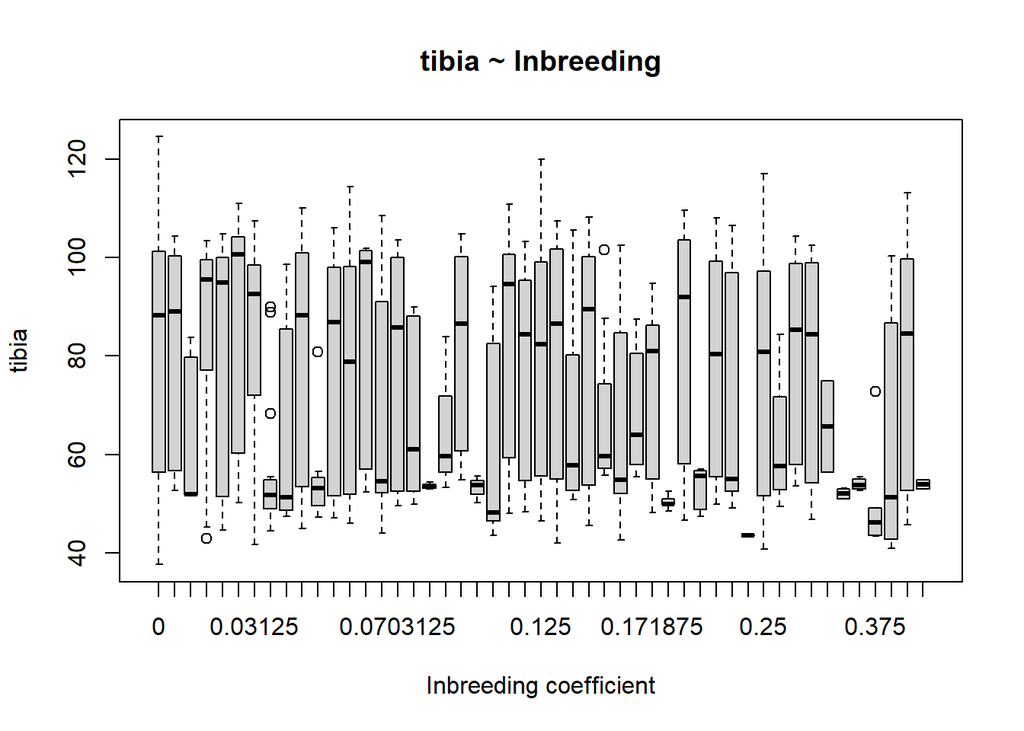

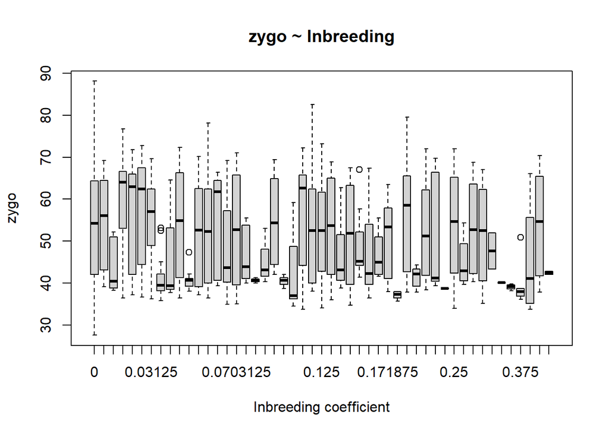

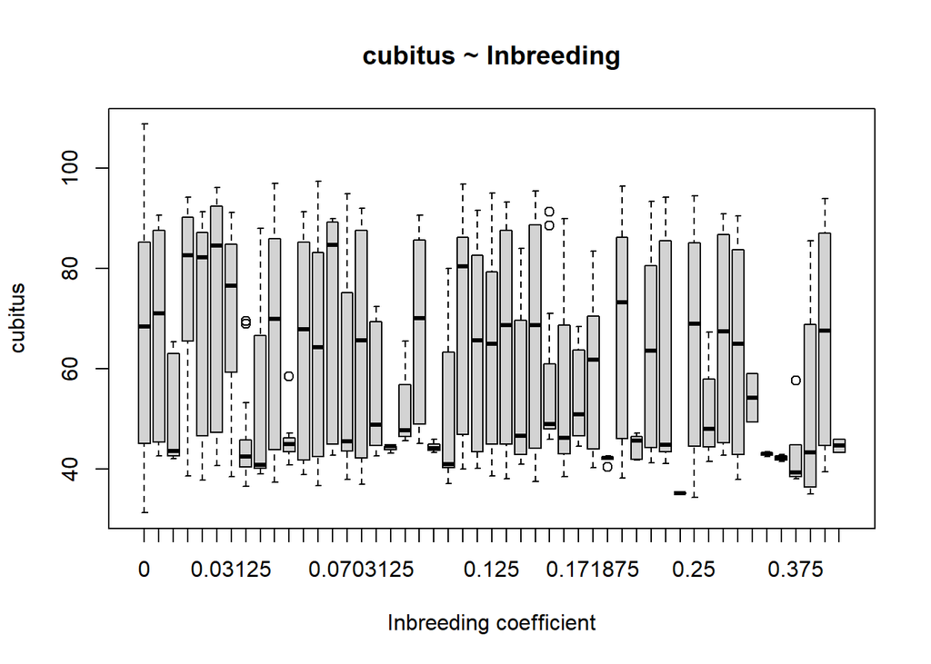